# PhonRNN

First, we include all required functions for the analysis, contained in `analysis/utils.R`.

```r
# custom functions
source("utils.R")
```

Some parameters need to be set, in particular the location of the results folder (which will probably vary if you run the model yourself.)

```r
# location of the results folder
results_folder <- '../results'

# summary file
summary_data = read.csv(paste0(results_folder, "/summary.csv"))

# probabilities of all words, combined into an easy format and enriched with summary results as well
# warning: this line might take a minute to run
enriched_words = utils$combine(results_folder, "final_eval-agg.csv")

# for running baselines on human judgment data. This particular data is available from: https://sites.google.com/site/rdaland/publications/Daland_etal_2011__AverageScores.csv?attredirects=0&d=1
daland_et_al_2011 <- "../baselines/Daland-et-al_2011.csv"
```

## Timecourse Data

We can analyze the performance of the models across the timecourse of training, in order to see how quickly each model attains its best performance.

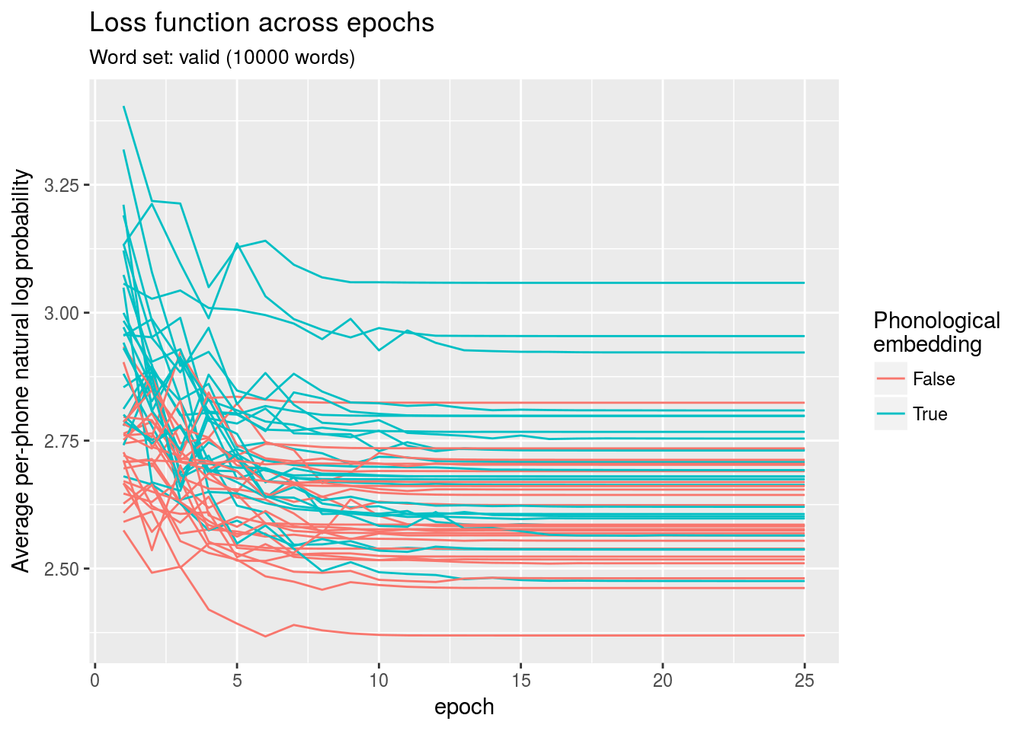

```r
# using performance on validation data
utils$plot_timecourse(enriched_words, summary_data, "valid")
```

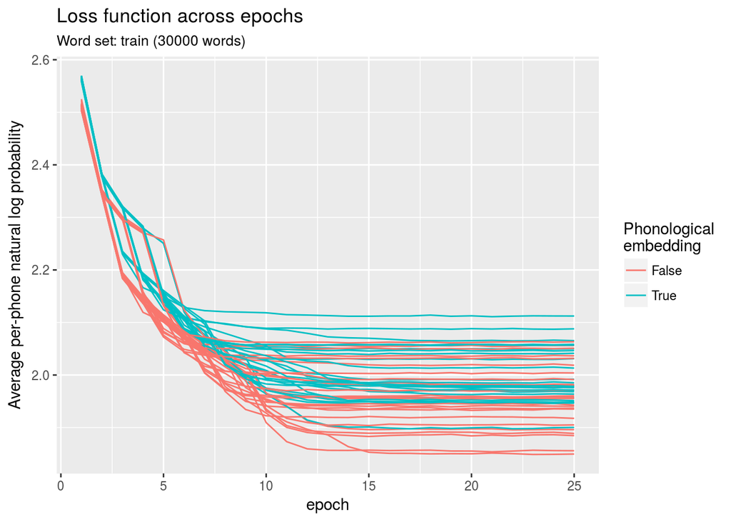

```r
# using performance on training data
# (less informative, but good check that the model has converged)
utils$plot_timecourse(enriched_words, summary_data, "train")
```

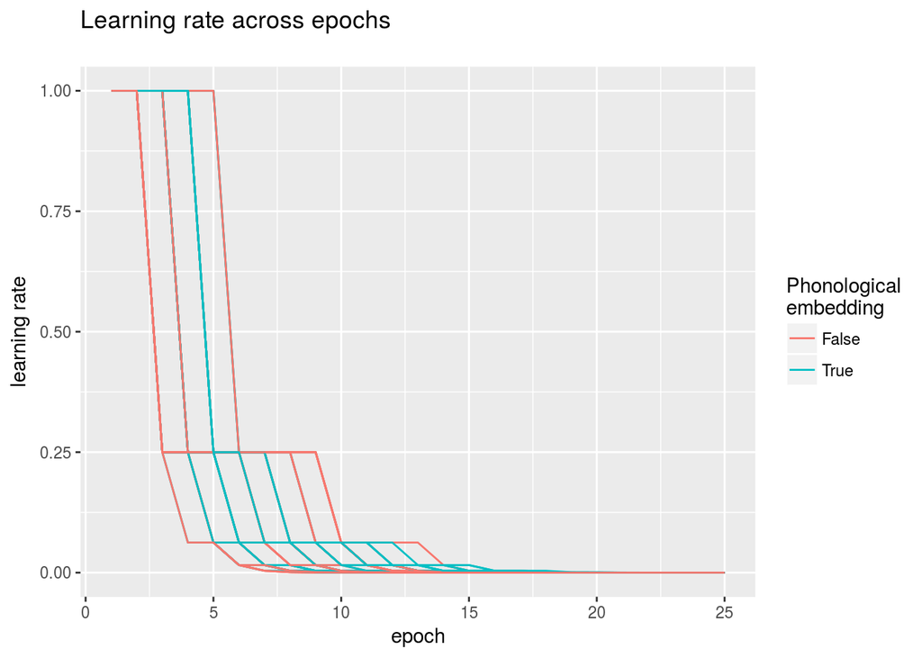

```r
# how does the learning rate change during training?
utils$plot_timecourse(enriched_words, summary_data)
```

## Final Evaluations

These are evaluations performed on the final state of the model, after training. This plot compares feature-aware and feature-naive conditions, in terms of natural log likelihood assigned to the words in the unseen test set.

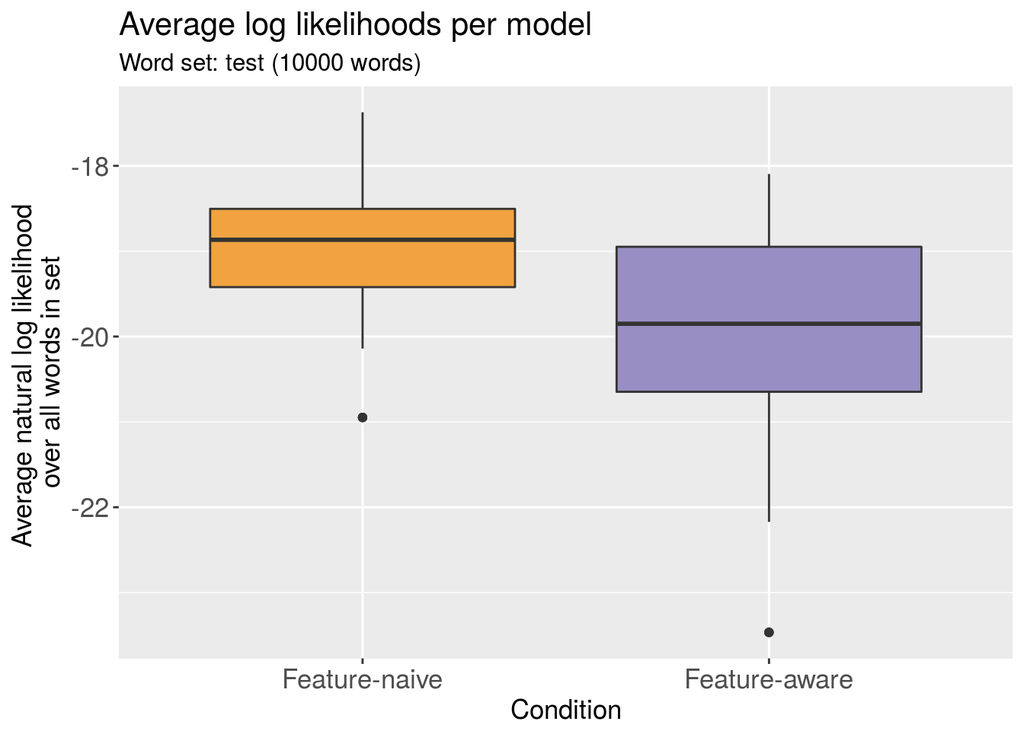

```r
utils$plot_data(enriched_words, split = "test")
```

```r
# perform Wilcox test
phonol_aware = subset(enriched_words, split_name == "test" & phonol_emb == "True")
phonol_naive = subset(enriched_words, split_name == "test" & phonol_emb == "False")
wilcox.test(phonol_aware$value, phonol_naive$value)
```

```
##
##  Wilcoxon rank sum test with continuity correction
##
## data:  phonol_aware$value and phonol_naive$value
## W = 2.8693e+10, p-value < 2.2e-16
## alternative hypothesis: true location shift is not equal to 0
```

```r
print(paste0("On average, the log probability assigned to the test corpus by phonologically aware models was ",
             mean(phonol_aware$value),
             ", while that assigned by phonologically naive models was",
             mean(phonol_naive$value), "."))
```

```
## [1] "On average, the log probability assigned to the test corpus by phonologically aware models was -20.6734207565269, while that assigned by phonologically naive models was-19.7869135148029."
```

## Clustering

We perform our cluster analysis on both the trained and untrained embeddings.

```r
trained_embs <- utils$get_embeddings(results_folder, trained = TRUE)
untrained_embs <- utils$get_embeddings(results_folder, trained = FALSE)
```

Generally, we are only interested in plotting the embeddings for certain models–usually, the models that assign the highest average log-likelihood to the test data.

```r
# summarize models by accuracy
acc_summary <- utils$summarize_acc(enriched_words)

# find the best model, in each condition
best_naive <- utils$get_best(acc_summary, phonol_emb_cond = "False")
best_aware <- utils$get_best(acc_summary, phonol_emb_cond = "True")
```

### Heatmaps

Armed with this metadata, we can plot heatmaps of our learned (and unlearned) embeddings.

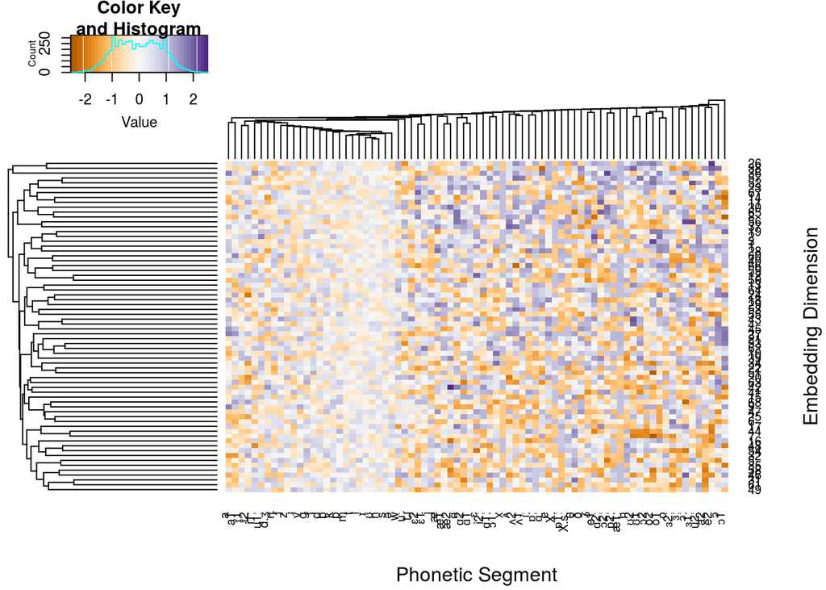

```r
utils$create_heat(trained_embs, best_naive)
```

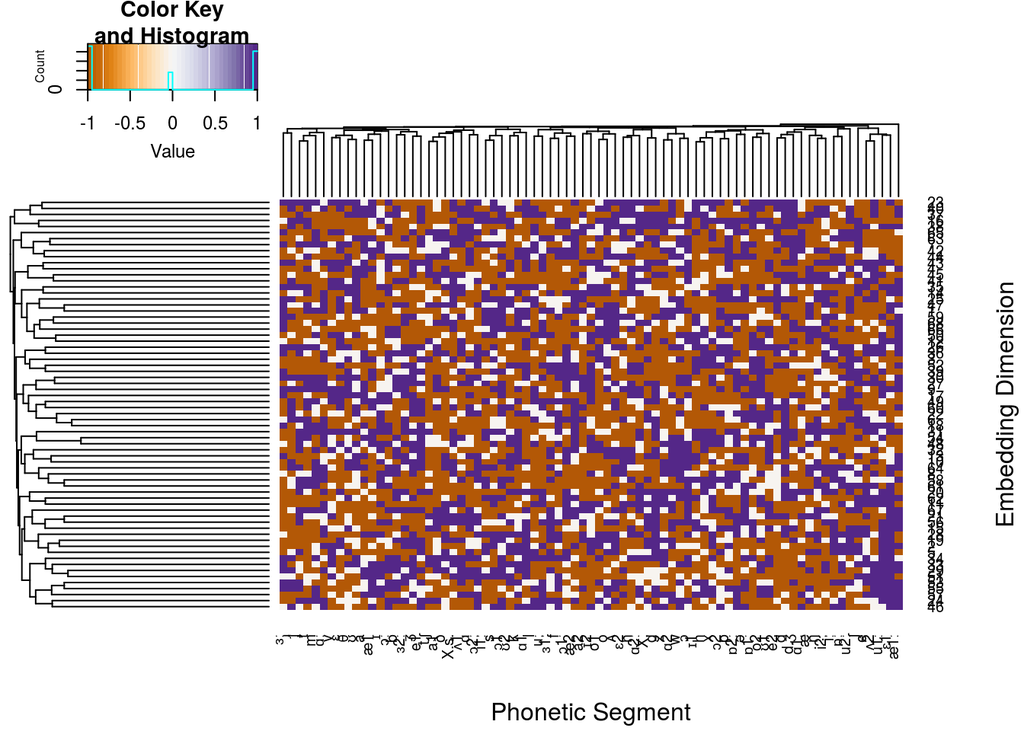

```r
utils$create_heat(untrained_embs, best_naive)
```

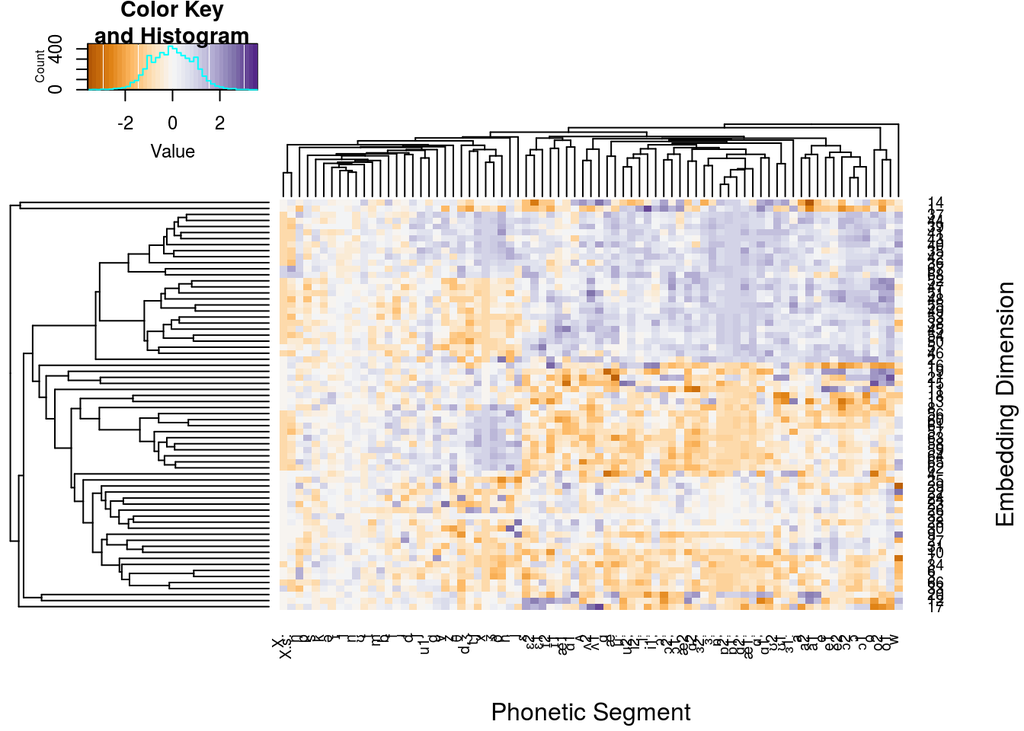

```r
utils$create_heat(trained_embs, best_aware)
```

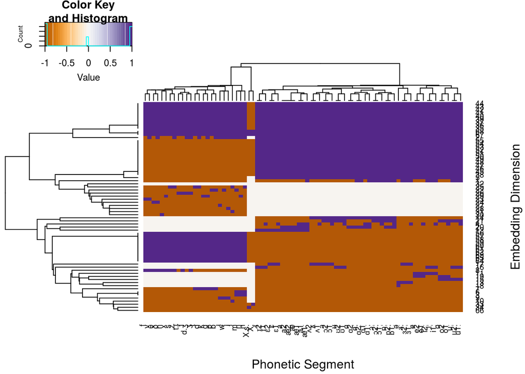

```r
utils$create_heat(untrained_embs, best_aware)
```

### Dendrograms

We can use these embeddings to generate more traditional dendrograms, according to agglomerative nesting methods. You should specify `phone_cats_file` as the path to a file with one line for each unique phone in your dataset, plus a line for the headers. These headers should be “phone” for the first column, and the category index of your choice for the second column. (See `analysis/phone_cats.csv` for an example.)

```r
phone_cats_file <- "phone_cats.csv"

utils$plot_dendro(trained_embs, best_naive, phone_cats_file)
```

[output not shown]

```r
utils$plot_dendro(untrained_embs, best_naive, phone_cats_file)
```

[output not shown]

```r
utils$plot_dendro(trained_embs, best_aware, phone_cats_file)
```

[output not shown]

```r
utils$plot_dendro(untrained_embs, best_aware, phone_cats_file)
```

[output not shown]

## Correlations with Human Judgments on Nonce Words

```r
# read in just the model probabilities on Daland et al., 2011 words
model_probs = utils$combine(results_folder, words_file = 'daland-probs.csv')
human_probs = subset(read.csv(daland_et_al_2011),
                     select = c("phono_ipa", "score"))

# merge data into one big dataframe
mh_probs = merge(model_probs, human_probs, by.x = "word", by.y = "phono_ipa", all=FALSE)


# run a correlation for each random instantiation
unique_models = unique(mh_probs[c("run_cond", "phonol_emb")])
unique_models['est'] <- rep(NA, nrow(unique_models)) # estimate of correlation coefficient
unique_models$sig =rep(NA, nrow(unique_models)) # p-value
unique_models$stat = rep(NA, nrow(unique_models)) # test statistic
unique_models$nh = rep(NA, nrow(unique_models)) # null hypothesis

for (m in 1:nrow(unique_models)) {
  unique_model_row = unique_models[m,]
  test_data = subset(mh_probs, run_cond == unique_model_row$run_cond, select=c("score", "value"))
  cor_test = cor.test(test_data$score, test_data$value,
                      method = "spearman")

  # store variables
  unique_models[m,'est'] = cor_test$estimate
  unique_models[m,'sig'] = cor_test$p.value
  unique_models[m,'stat']= cor_test$statistic
  unique_models[m,'nh'] = cor_test$null.value
}
```

[output not shown]

[output cut: 94 more lines]

[output not shown]

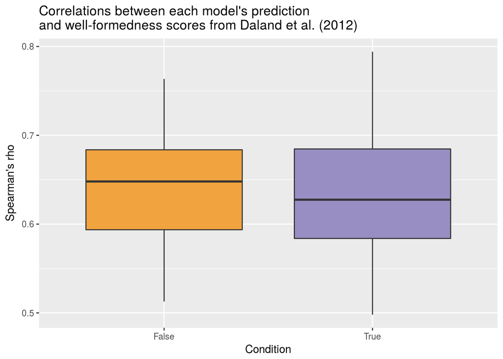

```r
# Does one condition do well over the other?
ggplot(data = unique_models, aes(x = phonol_emb, y = est, fill = phonol_emb)) +
  geom_boxplot() +
  labs(y = "Spearman\'s rho",
         x = "Condition",
         title="Correlations between each model's prediction\nand well-formedness scores from Daland et al. (2012)",
  scale_x_discrete(breaks = c("True", "False"),
                   labels= c("Feature-aware", "Feature-naive"))) +
  theme(legend.position = "none") +
  scale_fill_manual(values = brewer.pal(n=3, name="PuOr")[c(1,3)])
```